# bank term deposit

### Predicting whether a client will subscribe (yes/no) a term deposit

#### References

1. Title: Bank Marketing
2. Sources Created by: Paulo Cortez (Univ. Minho) and Sérgio Moro (ISCTE-IUL) @ 2012
3. Past Usage:

   The full dataset was described and analyzed in:

   S. Moro, R. Laureano and P. Cortez. Using Data Mining for Bank Direct Marketing: An Application of the CRISP-DM Methodology. In P. Novais et al. (Eds.), Proceedings of the European Simulation and Modelling Conference - ESM'2011, pp. 117-121, Guimarães, Portugal, October, 2011. EUROSIS.
4. Relevant Information:

   The data is related with direct marketing campaigns of a Portuguese banking institution. The marketing campaigns were based on phone calls. Often, more than one contact to the same client was required, in order to access if the product (bank term deposit) would be (or not) subscribed.

   There are two datasets: 1) bank-full.csv with all examples, ordered by date (from May 2008 to November 2010). 2) bank.csv with 10% of the examples (4521), randomly selected from bank-full.csv. The smallest dataset is provided to test more computationally demanding machine learning algorithms (e.g. SVM).

   The classification goal is to predict if the client will subscribe a term deposit (variable y).
5. Number of Instances: 45211 for bank-full.csv (4521 for bank.csv)
6. Number of Attributes: 16 + output attribute.
7. Attribute information:

   For more information, read [Moro et al., 2011].

   Input variables: #### bank client data: 1 - age (numeric)  
   2 - job : type of job (categorical: "admin.","unknown","unemployed","management","housemaid","entrepreneur","student","blue-collar","self-employed","retired","technician","services")  
   3 - marital : marital status (categorical: "married","divorced","single"; note: "divorced" means divorced or widowed)  
   4 - education (categorical: "unknown","secondary","primary","tertiary")  
   5 - default: has credit in default? (binary: "yes","no")  
   6 - balance: average yearly balance, in euros (numeric)  
   7 - housing: has housing loan? (binary: "yes","no")  
   8 - loan: has personal loan? (binary: "yes","no")

   #### related with the last contact of the current campaign: 9 - contact: contact communication type (categorical: "unknown","telephone","cellular")  
   10 - day: last contact day of the month (numeric)  
   11 - month: last contact month of year (categorical: "jan", "feb", "mar", ..., "nov", "dec")  
   12 - duration: last contact duration, in seconds (numeric)  
   #### other attributes: 13 - campaign: number of contacts performed during this campaign and for this client (numeric, includes last contact)  
   14 - pdays: number of days that passed by after the client was last contacted from a previous campaign (numeric, -1 means client was not previously contacted)  
   15 - previous: number of contacts performed before this campaign and for this client (numeric)  
   16 - poutcome: outcome of the previous marketing campaign (categorical: "unknown","other","failure","success")

   #### Output variable (desired target): 17 - y - has the client subscribed a term deposit? (binary: "yes","no")
8. Missing Attribute Values: None

```python
import pandas as pd

# read the data
df = pd.read_csv('./data/bank.csv', sep = ';')
df
```

|  | age | job | marital | education | default | balance | housing | loan | contact | day | month | duration | campaign | pdays | previous | poutcome | y |
| --- | --- | --- | --- | --- | --- | --- | --- | --- | --- | --- | --- | --- | --- | --- | --- | --- | --- |
| 0 | 30 | unemployed | married | primary | no | 1787 | no | no | cellular | 19 | oct | 79 | 1 | -1 | 0 | unknown | no |
| 1 | 33 | services | married | secondary | no | 4789 | yes | yes | cellular | 11 | may | 220 | 1 | 339 | 4 | failure | no |
| 2 | 35 | management | single | tertiary | no | 1350 | yes | no | cellular | 16 | apr | 185 | 1 | 330 | 1 | failure | no |
| 3 | 30 | management | married | tertiary | no | 1476 | yes | yes | unknown | 3 | jun | 199 | 4 | -1 | 0 | unknown | no |
| 4 | 59 | blue-collar | married | secondary | no | 0 | yes | no | unknown | 5 | may | 226 | 1 | -1 | 0 | unknown | no |
| ... | ... | ... | ... | ... | ... | ... | ... | ... | ... | ... | ... | ... | ... | ... | ... | ... | ... |
| 4516 | 33 | services | married | secondary | no | -333 | yes | no | cellular | 30 | jul | 329 | 5 | -1 | 0 | unknown | no |
| 4517 | 57 | self-employed | married | tertiary | yes | -3313 | yes | yes | unknown | 9 | may | 153 | 1 | -1 | 0 | unknown | no |
| 4518 | 57 | technician | married | secondary | no | 295 | no | no | cellular | 19 | aug | 151 | 11 | -1 | 0 | unknown | no |
| 4519 | 28 | blue-collar | married | secondary | no | 1137 | no | no | cellular | 6 | feb | 129 | 4 | 211 | 3 | other | no |
| 4520 | 44 | entrepreneur | single | tertiary | no | 1136 | yes | yes | cellular | 3 | apr | 345 | 2 | 249 | 7 | other | no |

4521 rows × 17 columns

```python
# check for null, missing values
df.isnull().values.any()
```

```
False
```

No missing values

```python
dups = df[df.duplicated(keep=False)]
dups.shape
```

```
(0, 17)
```

No duplicates

```python
print(df.shape)
df.dtypes
```

```
(4521, 17)
```

```
age           int64
job          object
marital      object
education    object
default      object
balance       int64
housing      object
loan         object
contact      object
day           int64
month        object
duration      int64
campaign      int64
pdays         int64
previous      int64
poutcome     object
y            object
dtype: object
```

10 categorical variables (job, marital, education, default, housing, loan, contact , month, poutcome, y)  
7 continuous variables (age, balance, day, duration, campaign, pdays, previous)  
y is the labeled target with values yes or no.  
A supervised ML approach, specically binary classification would be appropriate

```python
# value counts of each variable
for col in df.columns:
    print("\n---- %s ---" % col)
    print(df[col].value_counts())
```

```
---- age ---
34    231
32    224
31    199
36    188
33    186
     ...
76      2
84      1
81      1
86      1
87      1
Name: age, Length: 67, dtype: int64

---- job ---
management       969
blue-collar      946
technician       768
admin.           478
services         417
retired          230
self-employed    183
entrepreneur     168
unemployed       128
housemaid        112
student           84
unknown           38
Name: job, dtype: int64

---- marital ---
married     2797
single      1196
divorced     528
Name: marital, dtype: int64

---- education ---
secondary    2306
tertiary     1350
primary       678
unknown       187
```

[output cut: 172 more lines]

```
15       1
25       1
Name: previous, dtype: int64

---- poutcome ---
unknown    3705
failure     490
other       197
success     129
Name: poutcome, dtype: int64

---- y ---
no     4000
yes     521
Name: y, dtype: int64
```

Looking at the target variable (y/n for subscription), we see it's very imbalanced between yes and no classes. 4000 no vs. 521 yes or 88% to 12%

```python
df["y"].value_counts()/ df["y"].shape[0]
```

```
no     0.88476
yes    0.11524
Name: y, dtype: float64
```

job, education have 'unknown' values which can be dropped as part of data cleansing

```python
df = df.drop(df[df.job == 'unknown'].index)
df = df.drop(df[df.education == 'unknown'].index)

print(df.job.value_counts())
print(df.education.value_counts())
df.shape
```

```
management       942
blue-collar      905
technician       746
admin.           461
services         404
retired          216
self-employed    179
entrepreneur     157
unemployed       126
housemaid        107
student           68
Name: job, dtype: int64
secondary    2298
tertiary     1342
primary       671
Name: education, dtype: int64
```

```
(4311, 17)
```

Number of records reduced from 4521 to 4311

#### summary statistics for numeric values

```python
df.describe()
```

|  | age | balance | day | duration | campaign | pdays | previous |
| --- | --- | --- | --- | --- | --- | --- | --- |
| count | 4311.000000 | 4311.000000 | 4311.000000 | 4311.000000 | 4311.000000 | 4311.000000 | 4311.000000 |
| mean | 40.970309 | 1410.662723 | 15.908142 | 264.833449 | 2.805382 | 39.741591 | 0.544885 |
| std | 10.500185 | 3015.650889 | 8.205590 | 260.940391 | 3.134040 | 100.048485 | 1.705530 |
| min | 19.000000 | -3313.000000 | 1.000000 | 4.000000 | 1.000000 | -1.000000 | 0.000000 |
| 25% | 33.000000 | 66.500000 | 9.000000 | 104.000000 | 1.000000 | -1.000000 | 0.000000 |
| 50% | 39.000000 | 440.000000 | 16.000000 | 187.000000 | 2.000000 | -1.000000 | 0.000000 |
| 75% | 48.000000 | 1456.000000 | 21.000000 | 329.000000 | 3.000000 | -1.000000 | 0.000000 |
| max | 87.000000 | 71188.000000 | 31.000000 | 3025.000000 | 50.000000 | 871.000000 | 25.000000 |

### Visualization

#### univariate plots

```python
import seaborn as sns
import matplotlib.pyplot as plt

def plot_freq(data, cName):
    #f, ax = plt.subplots(figsize=(6, 10))
    sns.set(style="darkgrid")
    #sns.barplot(x=data.index, y=data.values, alpha=0.9)
    sns.barplot(y=data.index, x=data.values, alpha=0.9)

    plt.title('Frequency Distribution of '+ cName)
    plt.xlabel(cName, fontsize=11)
    plt.show()
```

#### histogram of numeric data

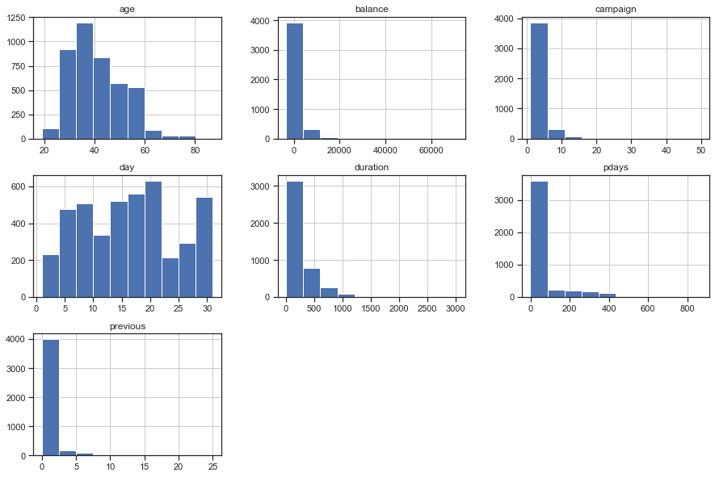

```python
df.hist(bins=10, figsize=(15,10))
plt.show()
```

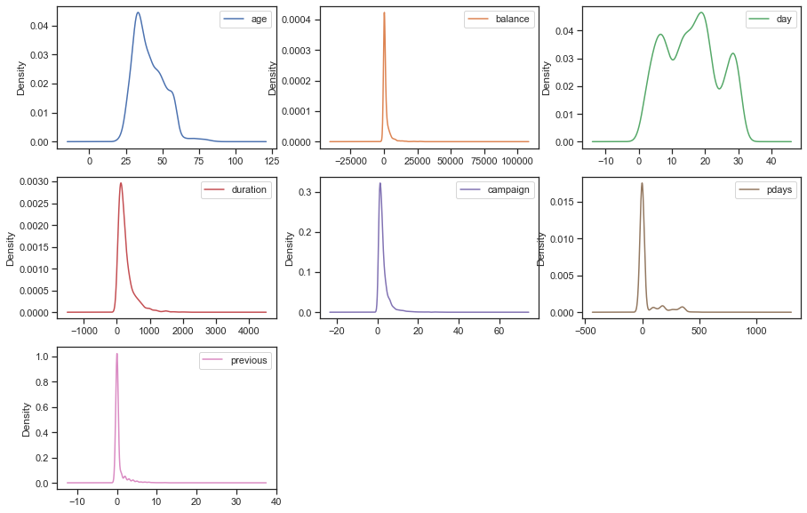

```python
# density plots
df.plot(figsize=(15,10), kind='density', subplots=True, layout=(3,3), sharex=False)
plt.show()
```

#### Freq distributions of categorical variable

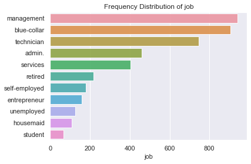

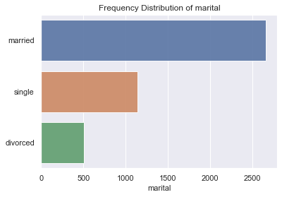

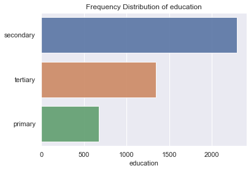

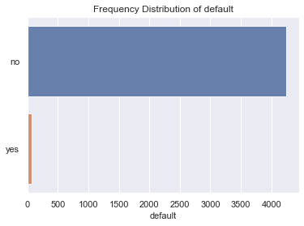

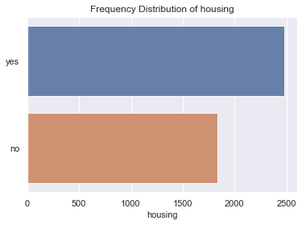

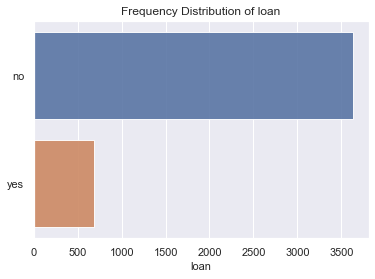

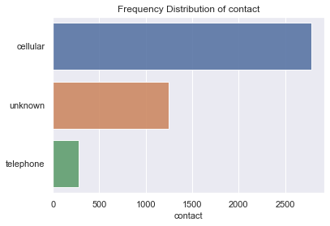

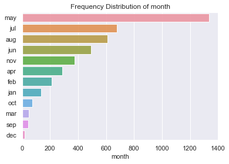

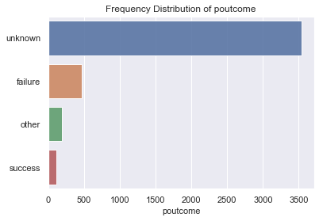

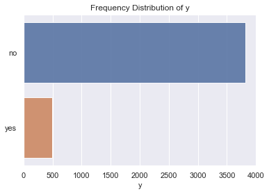

```python
# plot only categorical
for col in df.columns:
    if df[col].dtype  == 'int64':
        continue
    counts = df[col].value_counts()
    plot_freq(counts, col)
```

#### multivariate plots

correlation of continuous features

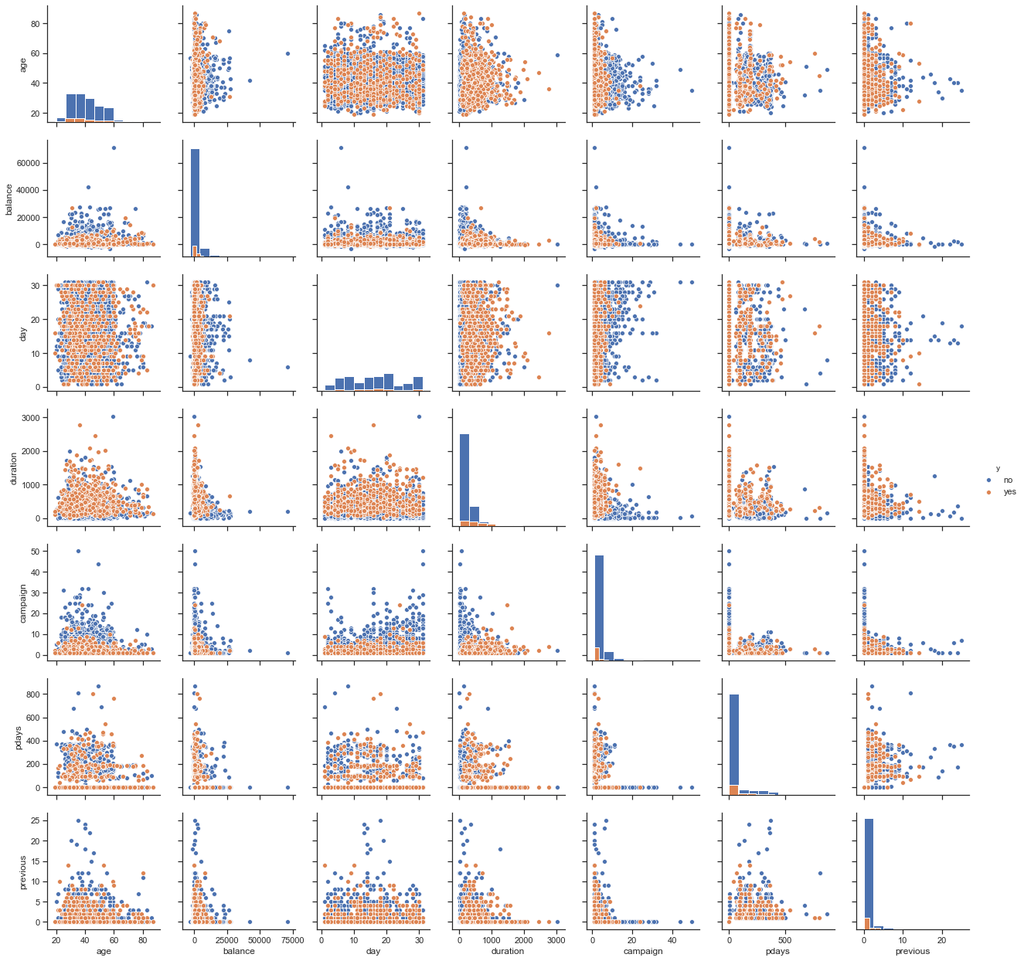

```python
import seaborn as sns
import matplotlib.pyplot as plt

sns.set(style='ticks', color_codes=True)
g = sns.pairplot(df, hue='y', diag_kind='hist')
plt.show()
```

```python
corr = df.corr()
corr.style.background_gradient(cmap='coolwarm')
```

|  | age | balance | day | duration | campaign | pdays | previous |
| --- | --- | --- | --- | --- | --- | --- | --- |
| age | 1.000000 | 0.087967 | -0.021427 | -0.004647 | 0.000558 | -0.012879 | -0.001519 |
| balance | 0.087967 | 1.000000 | -0.011892 | -0.017311 | -0.008167 | 0.008767 | 0.023308 |
| day | -0.021427 | -0.011892 | 1.000000 | -0.025676 | 0.165492 | -0.092925 | -0.058776 |
| duration | -0.004647 | -0.017311 | -0.025676 | 1.000000 | -0.071097 | 0.004305 | 0.016382 |
| campaign | 0.000558 | -0.008167 | 0.165492 | -0.071097 | 1.000000 | -0.092939 | -0.066189 |
| pdays | -0.012879 | 0.008767 | -0.092925 | 0.004305 | -0.092939 | 1.000000 | 0.575911 |
| previous | -0.001519 | 0.023308 | -0.058776 | 0.016382 | -0.066189 | 0.575911 | 1.000000 |

Most of the variables have little correlation. previous and pdays has a moderate correlation.

To better detect multicollinearity, we can use VIF. VIF determines the strength of correlation betweenindependent variables, where the VIF score represents how well the variable is explained by other independent variables.

- VIF starts at 1 and has no upper limit
- VIF = 1, no correlation between the independent variable and the other variables
- VIF exceeding 5 or 10 indicates high multicollinearity between this independent variable and the others

```python
from statsmodels.stats.outliers_influence import variance_inflation_factor

def calc_vif(X):

    # Calculating VIF
    vif = pd.DataFrame()
    vif["variables"] = X.columns
    vif["VIF"] = [variance_inflation_factor(X.values, i) for i in range(X.shape[1])]

    return(vif)


features = df[['age', 'balance', 'day', 'duration', 'campaign','pdays', 'previous']]
calc_vif(features)
```

|  | variables | VIF |
| --- | --- | --- |
| 0 | age | 5.106150 |
| 1 | balance | 1.228190 |
| 2 | day | 4.077257 |
| 3 | duration | 1.925907 |
| 4 | campaign | 1.832440 |
| 5 | pdays | 1.727036 |
| 6 | previous | 1.650242 |

### box plots

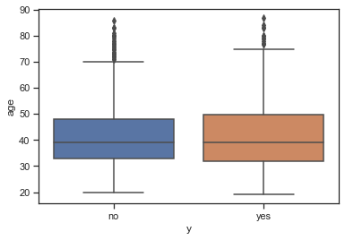

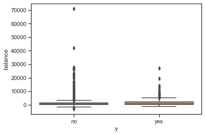

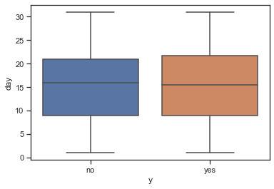

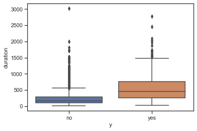

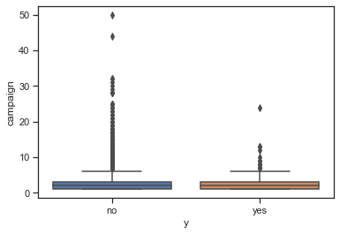

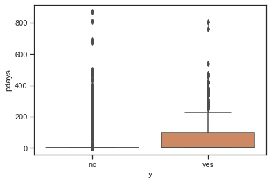

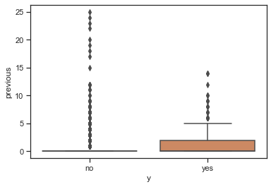

```python
#df.columns
for col in df.columns:
    if col == "y":
        continue
    if df[col].dtype  == 'int64':
        sns.boxplot(data=df, x="y", y=col)
        plt.show()
```

According to the dataset description, **duration** (last contact duration, in seconds) highly affects the output target (e.g., if duration=0 then y='no'). Yet, the duration is not known before a call is performed. Also, after the end of the call y is obviously known. Thus, this input should only be included for benchmark purposes and should be discarded if the intention is to have a realistic predictive model.

from the boxplots, we see that duration can be used to predict whether a customer will subscribe. So we drop the duriation field

```python
# drop duration
df = df.drop(['duration'], axis=1)
df.columns
```

```
Index(['age', 'job', 'marital', 'education', 'default', 'balance', 'housing',
       'loan', 'contact', 'day', 'month', 'campaign', 'pdays', 'previous',
       'poutcome', 'y'],
      dtype='object')
```

### Modeling

#### Encode Categorical features

```python
# encode categorical variables to dummy variables

df = pd.get_dummies(df, drop_first=True)
df
```

|  | age | balance | day | campaign | pdays | previous | job_blue-collar | job_entrepreneur | job_housemaid | job_management | ... | month_jun | month_mar | month_may | month_nov | month_oct | month_sep | poutcome_other | poutcome_success | poutcome_unknown | y_yes |
| --- | --- | --- | --- | --- | --- | --- | --- | --- | --- | --- | --- | --- | --- | --- | --- | --- | --- | --- | --- | --- | --- |
| 0 | 30 | 1787 | 19 | 1 | -1 | 0 | 0 | 0 | 0 | 0 | ... | 0 | 0 | 0 | 0 | 1 | 0 | 0 | 0 | 1 | 0 |
| 1 | 33 | 4789 | 11 | 1 | 339 | 4 | 0 | 0 | 0 | 0 | ... | 0 | 0 | 1 | 0 | 0 | 0 | 0 | 0 | 0 | 0 |
| 2 | 35 | 1350 | 16 | 1 | 330 | 1 | 0 | 0 | 0 | 1 | ... | 0 | 0 | 0 | 0 | 0 | 0 | 0 | 0 | 0 | 0 |
| 3 | 30 | 1476 | 3 | 4 | -1 | 0 | 0 | 0 | 0 | 1 | ... | 1 | 0 | 0 | 0 | 0 | 0 | 0 | 0 | 1 | 0 |
| 4 | 59 | 0 | 5 | 1 | -1 | 0 | 1 | 0 | 0 | 0 | ... | 0 | 0 | 1 | 0 | 0 | 0 | 0 | 0 | 1 | 0 |
| ... | ... | ... | ... | ... | ... | ... | ... | ... | ... | ... | ... | ... | ... | ... | ... | ... | ... | ... | ... | ... | ... |
| 4516 | 33 | -333 | 30 | 5 | -1 | 0 | 0 | 0 | 0 | 0 | ... | 0 | 0 | 0 | 0 | 0 | 0 | 0 | 0 | 1 | 0 |
| 4517 | 57 | -3313 | 9 | 1 | -1 | 0 | 0 | 0 | 0 | 0 | ... | 0 | 0 | 1 | 0 | 0 | 0 | 0 | 0 | 1 | 0 |
| 4518 | 57 | 295 | 19 | 11 | -1 | 0 | 0 | 0 | 0 | 0 | ... | 0 | 0 | 0 | 0 | 0 | 0 | 0 | 0 | 1 | 0 |
| 4519 | 28 | 1137 | 6 | 4 | 211 | 3 | 1 | 0 | 0 | 0 | ... | 0 | 0 | 0 | 0 | 0 | 0 | 1 | 0 | 0 | 0 |
| 4520 | 44 | 1136 | 3 | 2 | 249 | 7 | 0 | 1 | 0 | 0 | ... | 0 | 0 | 0 | 0 | 0 | 0 | 1 | 0 | 0 | 0 |

4311 rows × 40 columns

```python
# the target was renamed
df['y_yes'].value_counts()
```

```
0    3813
1     498
Name: y_yes, dtype: int64
```

```python
# get features and targt

X = df.drop(columns='y_yes')  # features only
y = df['y_yes'].copy()        # target
y
```

```
0       0
1       0
2       0
3       0
4       0
       ..
4516    0
4517    0
4518    0
4519    0
4520    0
Name: y_yes, Length: 4311, dtype: uint8
```

#### standarize numeric features

```python
from sklearn.preprocessing import StandardScaler

# scale numeric variables
X = StandardScaler().fit_transform(X)
X
```

```
array([[-1.04489412,  0.12480919,  0.37684272, ..., -0.21353657,
        -0.16702394,  0.46816045],
       [-0.75915172,  1.12039798, -0.59821556, ..., -0.21353657,
        -0.16702394, -2.13601981],
       [-0.56865678, -0.0201183 ,  0.01119587, ..., -0.21353657,
        -0.16702394, -2.13601981],
       ...,
       [ 1.52678755, -0.37000044,  0.37684272, ..., -0.21353657,
        -0.16702394,  0.46816045],
       [-1.23538906, -0.09075801, -1.20762699, ...,  4.68303866,
        -0.16702394, -2.13601981],
       [ 0.28857045, -0.09108965, -1.57327384, ...,  4.68303866,
        -0.16702394, -2.13601981]])
```

### Splitting the dataset

```python
from sklearn.model_selection import train_test_split

X_train, X_test, y_train, y_test = train_test_split(X, y, test_size=0.20, random_state = 0)


print('80% Train', X_train.shape, y_train.shape)
print('20 % Test', X_test.shape, y_test.shape)
```

```
80% Train (3448, 39) (3448,)
20 % Test (863, 39) (863,)
```

### Train and Predict the Mode

```python
#X_train
#y_train

print ('before balancing:')
y_train.value_counts()
```

```
before balancing:
```

```
0    3046
1     402
Name: y_yes, dtype: int64
```

There are various approaches to **handling unbalanced datasets**. One approach is Synthetic Minority Oversampling Technique or **SMOTE**

Here new examples are synthesized from the existing examples. This is a type of data augmentation for the minority class referred to as the Synthetic Minority Oversampling Technique, or SMOTE for short.

- https://machinelearningmastery.com/smote-oversampling-for-imbalanced-classification/

```python
#!pip install imblearn
from imblearn.over_sampling import SMOTE

oversample = SMOTE()
X_train, y_train = oversample.fit_resample(X_train, y_train)

print ('after balancing')
y_train.value_counts()
```

```
after balancing
```

```
1    3046
0    3046
Name: y_yes, dtype: int64
```

#### Logistic Regression most common for binary classisfication

```python
from sklearn.linear_model import LogisticRegression
from sklearn.linear_model import LogisticRegressionCV # with Cross validation


model = LogisticRegression(
                             #cv=5,
                             #scoring='roc_auc',
                             penalty='l2',
                             class_weight='balanced',
                             #verbose=1,
                             n_jobs=-1,
                             max_iter = 500
                            )

# fit and train
model.fit(X_train, y_train)

# mean accuracy
score = cross_val_score(model, X_train, y_train, cv=5)
mean = score.mean()*100
std =  score.std()*100
print(f"Mean Accuracy: mean ({mean})  std ({std})")
```

```
Mean Accuracy: mean (67.8429248987366)  std (1.2557237377973147)
```

```
AUC score:  0.6261204367666233
              precision    recall  f1-score   support

           0       0.92      0.72      0.81       767
           1       0.19      0.53      0.28        96

    accuracy                           0.70       863
   macro avg       0.56      0.63      0.55       863
weighted avg       0.84      0.70      0.75       863
```

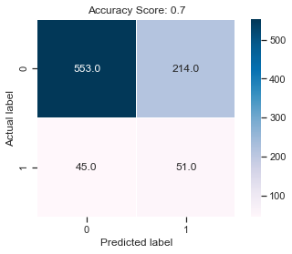

```python
# predict
y_pred = model.predict(X_test)

# Evaluate
from sklearn.model_selection import cross_val_score
from sklearn.metrics import accuracy_score
from sklearn.metrics import roc_auc_score
from sklearn.metrics import classification_report
from sklearn.metrics import confusion_matrix as cm

def getPerformance(y_true, y_pred):

    print("AUC score: ", roc_auc_score(y_test, y_pred))
    print(classification_report(y_true, y_pred))

    score = round(accuracy_score(y_true, y_pred),3)
    cm1 = cm(y_test, y_pred)
    sns.heatmap(cm1, annot=True, fmt=".1f", linewidths=.3,
        square = True, cmap = 'PuBu')
    plt.ylabel('Actual label')
    plt.xlabel('Predicted label')
    plt.title('Accuracy Score: {0}'.format(score), size = 12)
    plt.show()


getPerformance(y_test, y_pred)
```

At this point we can try to improve this model with hyper-parameters or try other predictictive models